# Do Online Mental Health Apps Actually Reach the People Who Need Them Most?

A Data-Driven Investigation into Telehealth Equity in the United States

Authors

Dhwanika Narang

Helly Harshad Shah

Khushwant Khatri

Felisita Cheung

Published

May 1, 2026

# The Problem Nobody Is Solving

Fifty-seven percent of American adults living with a diagnosed mental illness receive no treatment at all. Not inadequate treatment. No treatment.

At the same time, the global market for online mental health platforms surpassed five billion dollars in 2024, with BetterHelp and Teladoc alone generating $2.57 billion in revenue. Five hundred million mental health app downloads have been recorded worldwide. By every headline metric, the industry is booming.

And yet the treatment gap persists.

This tension is the animating force behind our project. If telehealth platforms are growing this fast, are they actually reaching the people who need them most: low-income adults, racial and ethnic minorities, older adults in medically underserved areas? Or is the boom concentrated among people who would have found care anyway?

> **Do online mental health apps actually reach the people who need them most, and if not, where is the biggest opportunity to fix that?**

To answer this question, we divided the problem into four specific analyses targeting demand, supply, equity, and geography.

# What We Already Knew: Situating the Project in Prior Work

Our project builds directly on four foundational studies.

- Mojtabai et al. (2016)
- Torous et al. (2021)
- McBain et al. (2023)
- Fortney et al. (2015)

Each of these studies examined only one dimension of the access problem at a time. Our project instead combines income, age, race, and geography simultaneously using post-pandemic 2024 data.

# Data: What We Used and Why It Has Limits

## CDC BRFSS 2024

The CDC BRFSS 2024 dataset (`n = 457,670`) served as the primary source for individual-level mental health burden.

The primary variables used included:

- `ADDEPEV3`
- `MENTHLTH`
- `_LLCPWT`
- `_METSTAT`
- `SEXVAR`
- `_AGE80`

A limitation is that the dedicated telehealth variable was removed from the 2024 BRFSS survey instrument. Therefore, diagnosed depression was used as a proxy for mental health need.

## ACS 2024 PUMS

The ACS 2024 PUMS dataset provided income, occupation, and geographic variables.

Primary variables included:

- `OCCP`
- `PWGTP`

Using ACS weighted estimates, we identified approximately 3.9 million mental health-related workers in the United States.

## BLS QCEW

The Bureau of Labor Statistics Quarterly Census of Employment and Wages (QCEW) was used to estimate therapist establishment counts.

## Teladoc and BetterHelp SEC Filings

SEC filings from Teladoc and BetterHelp between 2018 and 2024 were used to estimate platform growth and revenue expansion.

# What We Found: Four Answers, One Story

## Income, Not Age, Drives Mental Health Burden

### SQ1 — Dhwanika Narang

Income was one of the strongest predictors of depression burden.

Low-income adults aged 55–64 experienced the highest burden overall, with approximately 44.2% reporting depression-related indicators.

Young adults aged 18–34 clustered around similar depression rates regardless of income level. However, among older adults, income disparities became much more pronounced.

Low-income adults aged 35–54 also experienced the greatest cost barriers to healthcare access.

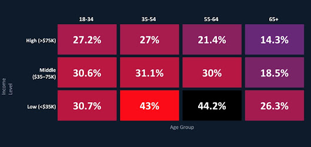

*Figure 1. Age × Income and Mental Health Burden*

## Platform Growth Has Massively Outpaced Provider Supply

### SQ2 — Felisita Cheung

BetterHelp’s U.S. revenue grew dramatically between 2018 and 2024.

Conservatively, our findings estimate approximately one therapist per 11,000 subscribers based on publicly discussed platform estimates.

The supply and demand imbalance may create quality-control bottlenecks as telehealth demand expands.

## Racial Gaps Persist and Likely Run Deeper Than Diagnosis Rates Suggest

### SQ3 — Helly Harshad Shah

White adults reported the highest diagnosed depression rates across most age groups, while Asian adults consistently reported the lowest diagnosed rates.

However, these findings likely reflect unequal access to diagnosis rather than actual burden differences.

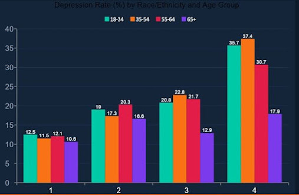

*Figure 2. Race × Age and Depression Rates*

## Rural Geography Matters Less Than Income

### SQ4 — Khushwant Khatri

Rural and urban depression rates were far more similar than expected.

Urban adults aged 18–34 actually experienced slightly higher cost barriers than rural adults.

These findings suggest that income is a stronger determinant of mental health burden than geography alone.

# Integrating the Findings

Together, the four analyses point toward one major conclusion:

> **The largest barrier to mental health access in the United States is economic access, not geography alone.**

Telehealth platforms have expanded rapidly, but provider shortages and unequal healthcare access continue to limit who receives actual treatment.

# Limitations and Next Steps

Three major limitations remain:

1. Missing TELEHLTH variable in BRFSS 2024
2. Self-report bias
3. Revenue is not identical to treatment access

Future work should incorporate: - insurance coverage data - prescribing data - anonymized telehealth session data - AI mental health platforms

# Conclusion

Our findings indicate that significantly more individuals report depression than the currently available mental health workforce can realistically support through direct therapy services.

Although metropolitan areas contain larger total numbers of adults reporting depression, proportion-based analysis shows that metro and non-metro differences become much smaller when population size is considered.

Most importantly, income consistently emerged as a stronger determinant of mental health burden than geography alone.

Overall, the analysis highlights both a major public health challenge and an important area for future healthcare innovation.